# Classification through Probabilistic Learning: Stellar Classification

Alejandro Macías Pastor

2024-02-28

# 1. Introduction

The data that will be studied in this project is astronomical data obtained through the Sloan Digital Sky Survey (SDSS), although the precise dataset has been obtained from Kaggle. The file is available [here](https://www.kaggle.com/datasets/fedesoriano/stellar-classification-dataset-sdss17).

The main objective of this astronomical survey was to identify astronomical objects based on their position in the sky and several photometric measurements. The following list contains all the variables found in the dataset, along with a brief description:

- **obj_ID**: the unique value that identifies the object within the catalog.
- **alpha**: Right Ascension angle.
- **delta**: Declination angle.
- **u**: Measurement from the Ultraviolet filter in the photometric system.
- **g**: Measurement from the Green filter in the photometric system.
- **r**: Measurement from the Red filter in the photometric system.
- **i**: Measurement from the Near-Infrared filter in the photometric system.
- **z**: Measurement from the Infrared filter in the photometric system.
- **run_ID**: Run Number used to identify the specific scan.
- **rerun_ID**: Rerun Number used to specify how the image was processed.
- **cam_col**: Camera column to identify the scanline within the run.
- **field_ID**: Field number to identify each field.
- **spec_obj_ID**: Unique ID used for optical spectroscopic objects.
- **redshif**: redshift value based on the increase in wavelength.
- **plate**: identifies each plate in SDSS (metallic plates that are part of the instrument).
- **MJD**: (Modified Julian) Date, used to indicate when the data was taken.
- **fiber_ID**: identifies the fiber that pointed the light at the focal plane in each observation.
- **class**: class of the astronomical object (galaxy, star or quasar).

```r
library(ggplot2)
library(caret)
library(dplyr)
library(GGally)
library(nnet)
set.seed(333) # for the sake of reproducibility
```

```r
# import the dataset
data = read.csv("star_classification.csv")
```

# 2.Data Preprocessing

## 2.1 Imputation and removal

Before creating any models, it is important to study in detail all the observations and variables, in order to both gain some insight and preprocess when needed to avoid later problems when creating models.

Since the first two columns are simply the observations index and a unique identifier of each object within the catalog, removing these two variables will not affect the classification task, since they are non-informative.

```r
data = data[-c(1,2)] # remove first two columns
```

Let us now check whether there are any missing values in any of the remaining variables:

```r
print("Count of missing values by column wise")
```

```
## [1] "Count of missing values by column wise"
```

```r
sapply(data, function(x) sum(is.na(x)))
```

```
##       alpha       delta           u           g           r           i
##          88         401           0           0          38           0
##           z      run_ID    rerun_ID     cam_col    field_ID spec_obj_ID
##           0           0           0           0           0           0
##       class    redshift       plate         MJD    fiber_ID
##           0         847           0           0           0
```

It is also worth noting that there is one observation (#79544) for which the variables `u`, `g` and `z` take the value -9999:

```r
data[data$u==-9999,] # find erroneous observation
```

```
##          alpha      delta     u     g       r        i     z run_ID rerun_ID
## 79544 224.0065 -0.6243039 -9999 -9999 18.1656 18.01675 -9999    752      301
##       cam_col field_ID  spec_obj_ID class     redshift plate   MJD fiber_ID
## 79544       2      537 3.731277e+18  STAR 8.934163e-05  3314 54970      162
```

Since this is physically impossible, we will consider these three values for this observation to be NAs:

```r
data$u[data$u == -9999] = NA
data$g[data$g == -9999] = NA
data$z[data$z == -9999] = NA
```

The imputation of the missing values can be easily done throught the `caret` library’s functionalities. In particular, a method based on the k-Nearest Neighbours algorithm will be used.

```r
imputer = caret::preProcess(data, method='knnImpute')
data = predict(imputer, data)
sapply(data, function(x) sum(is.na(x)))
```

```
##       alpha       delta           u           g           r           i
##           0           0           0           0           0           0
##           z      run_ID    rerun_ID     cam_col    field_ID spec_obj_ID
##           0           0           0           0           0           0
##       class    redshift       plate         MJD    fiber_ID
##           0           0           0           0           0
```

It is worth mentioning that the `preProcess` function also standardizes the columns of the dataset by default. For the sake of the subsequent EDA of the variables, this standardization will be reversed:

```r
# store the statistics to destandardize
destandard <- data.frame(col = names(imputer$mean),
                         mean = imputer$mean,
                         sd = imputer$std)
# undo the scaling
for(i in destandard$col){
 data[i] <- data[i]*imputer$std[i]+imputer$mean[i]
}
```

## 2.2 Exploratory Data Analysis

Let us now deal with each variable individually.

### Class

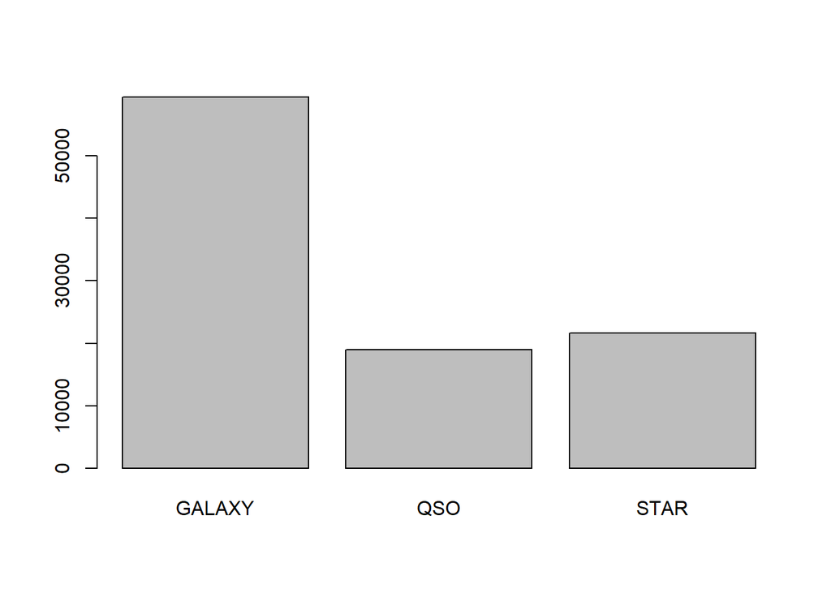

```r
data$class = factor(data$class)
plot(data$class)
```

```r
prop.table(table(data$class))
```

```
##
##  GALAXY     QSO    STAR
## 0.59445 0.18961 0.21594
```

```r
table(data$class)
```

```
##
## GALAXY    QSO   STAR
##  59445  18961  21594
```

The three different classes are clearly not well-balanced. Since this could impact negatively the performance of the models to be studied, it is necessary to balance the three classes. For this, there are two different options: upsampling or dowmsapling. The decision to downsample has been made in order to avoid introducing undesirable characteristics into the dataset that can come from repeating the same observations too many times, such as high correlations between variables.

Since the dataset has plenty of observations and the biggest difference comes from the `GALAXY` class, we will opt to mainly downsample said group and slightly downsample the `STAR` group as well. To do this, we can use the `downSample` function from the `caret` library:

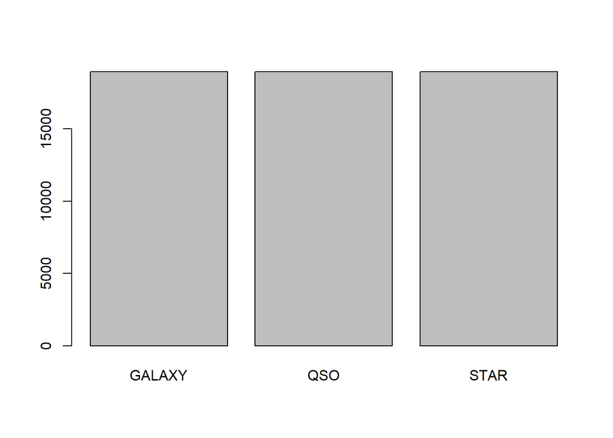

```r
# downSample glues the Class column at the end of the data frame by default
# so it is necessary to remove it from the input so it is not redundant
data = caret::downSample(x=subset(data, select= -class), y=data$class)

# double-check the proportions after downsampling
plot(data$Class)
```

```r
table(data$Class)
```

```
##
## GALAXY    QSO   STAR
##  18961  18961  18961
```

```r
prop.table(table(data$Class))
```

```
##
##    GALAXY       QSO      STAR
## 0.3333333 0.3333333 0.3333333
```

Now that the classes have been perfectly balanced, we can proceed to create the train-test partition that will be used later on in this report to train and test the different models. Considering the moderately big size of our dataset (56883 observations), the proportion used for the partition will be 50%-50% for training and testing, respectively:

```r
# create the partition
part = createDataPartition(data$Class, p = 0.5, list = FALSE)
# separate into train and test
data_train = data[part,]
data_test = data[-part,]
```

We can now proceed to study the rest of the variables with the observations from the training set. This is done so that there is absolutely no data leakage, that is, so that the information contained in the testing set does not influence in any way the models that will be trained.

### Alpha

Starting with the Right Ascension, we can see that it is symmetric (around about 180º), although far from being normally-distributed due to its very heavy tails.

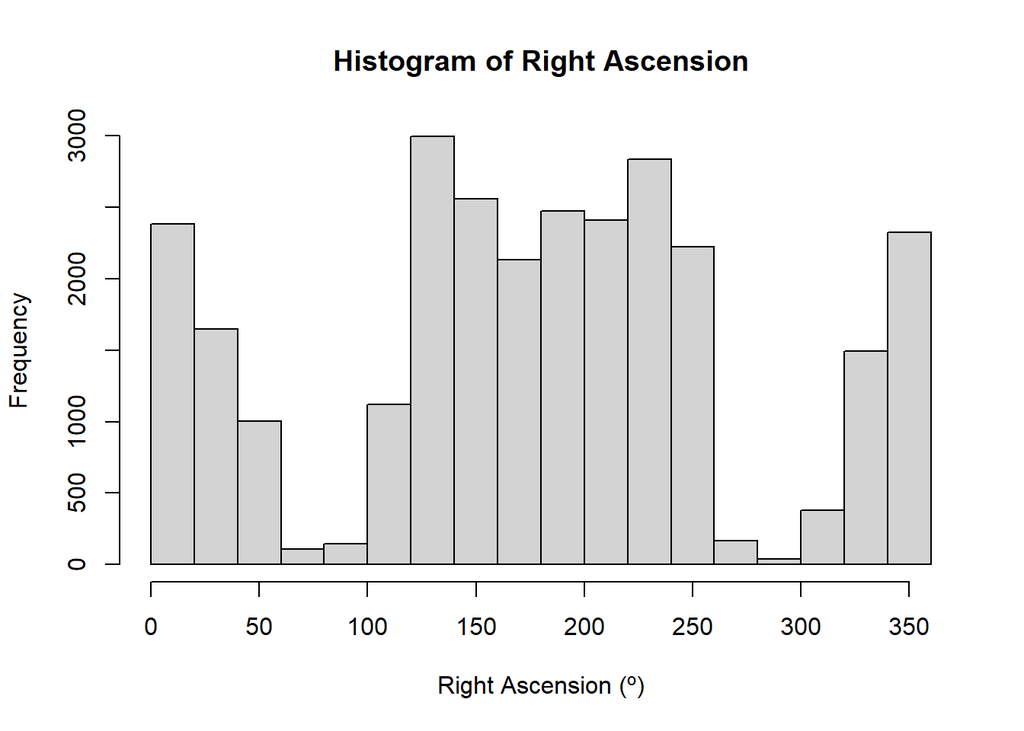

```r
hist(data_train$alpha, main='Histogram of Right Ascension', xlab='Right Ascension (º)')
```

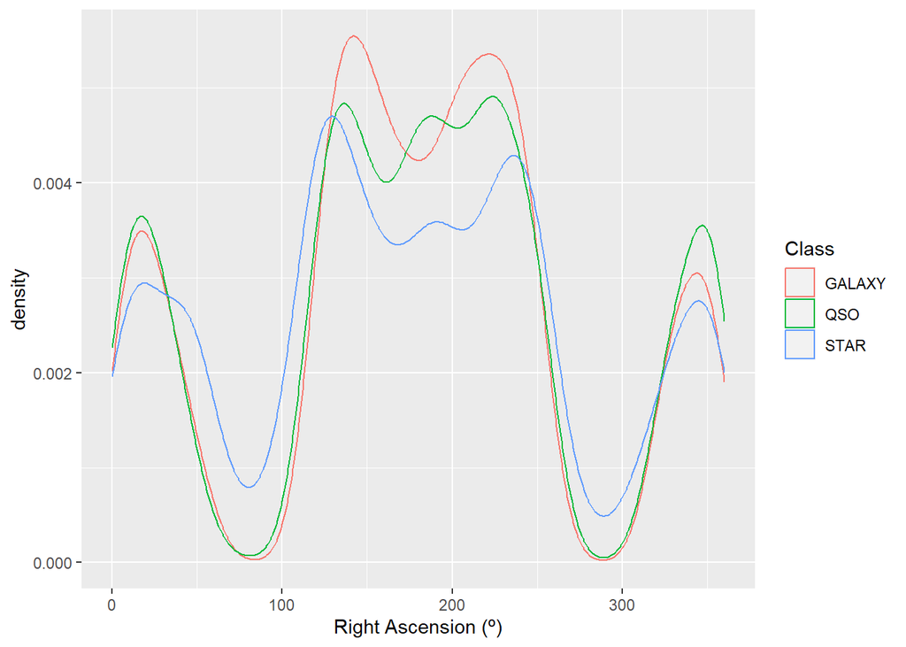

```r
ggplot(data_train, aes(x=alpha, color=Class)) +
  geom_density() +
  labs(x="Right Ascension (º)")
```

As far as differences in terms of the astronomical object class are concerned, the second graph does not seem to show any significant evidence for their existence.

### Delta

The declination shows a slightly more normal-like shape, although with a significant peak around 0º.

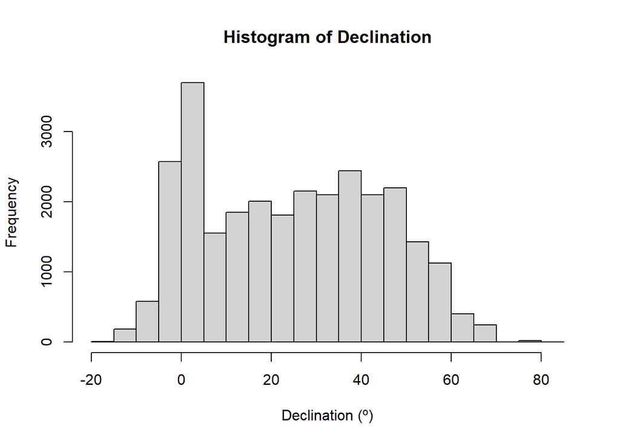

```r
hist(data_train$delta, main='Histogram of Declination', xlab="Declination (º)")
```

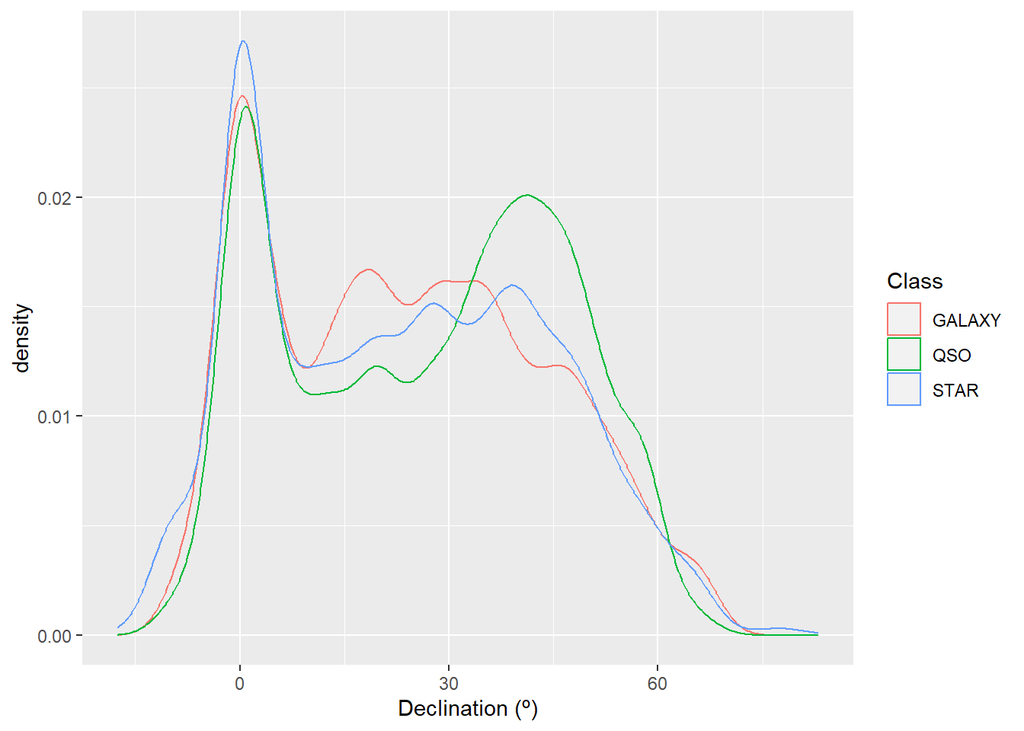

```r
ggplot(data_train, aes(x=delta, color=Class)) +
  geom_density() +
  labs(x="Declination (º)")
```

When considering the frequency of the different classes in terms of the declination, no significant difference seems to arise.

### u, g, r, i, z

When considering all the photometric measurements, we can notice a common pattern in the data coming from all different filters. When all together, the observations seem to follow somewhat of a normal distribution, whereas when separated into the three different groups some differences arise.

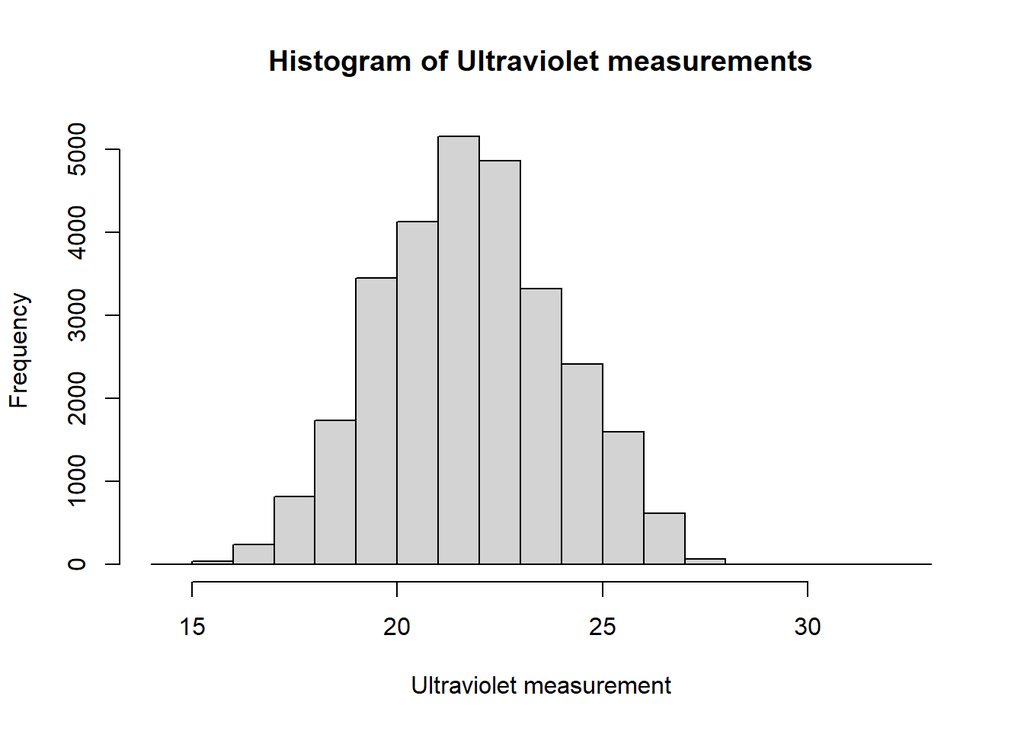

```r
hist(data_train$u, main='Histogram of Ultraviolet measurements', xlab='Ultraviolet measurement')
```

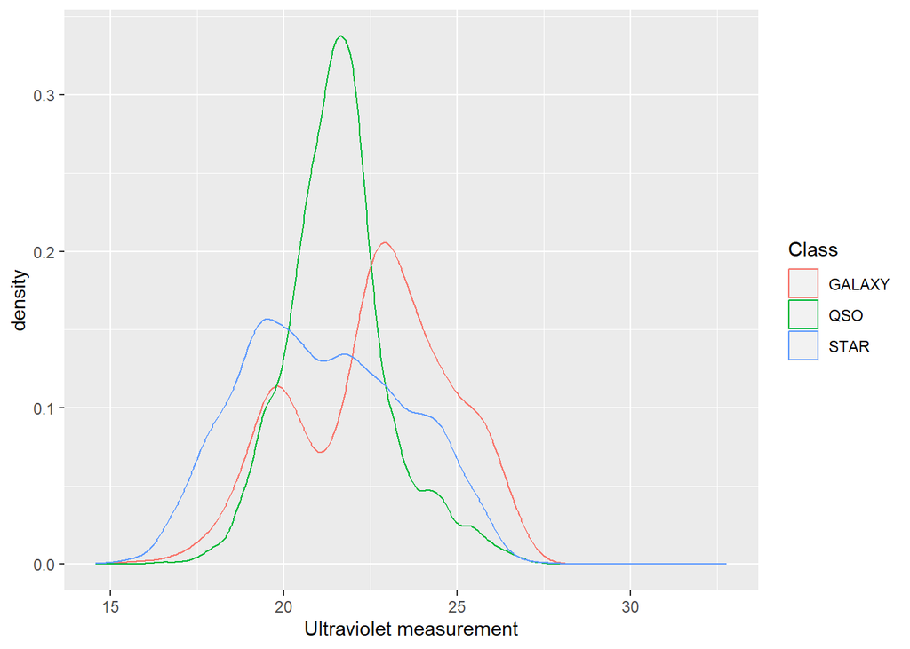

```r
ggplot(data_train, aes(x=u, color=Class)) +
  geom_density() +
  labs(x="Ultraviolet measurement")
```

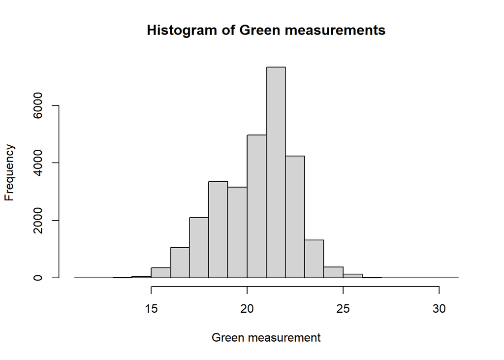

```r
hist(data_train$g, main='Histogram of Green measurements', xlab='Green measurement')
```

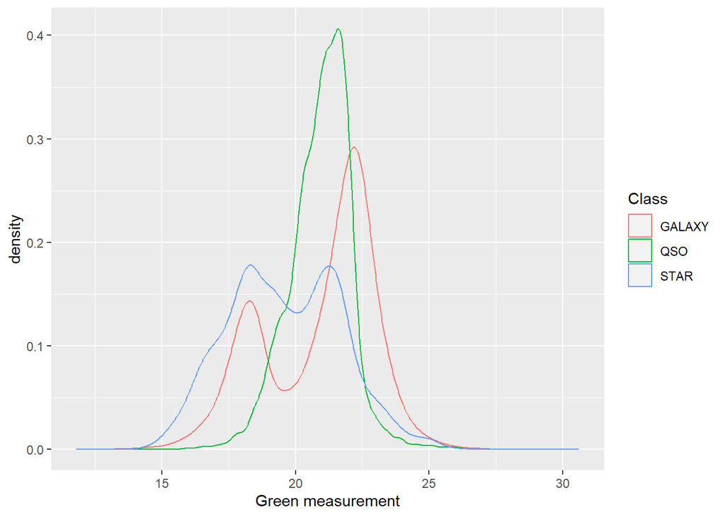

```r
ggplot(data_train, aes(x=g, color=Class)) +
  geom_density() +
  labs(x="Green measurement")
```

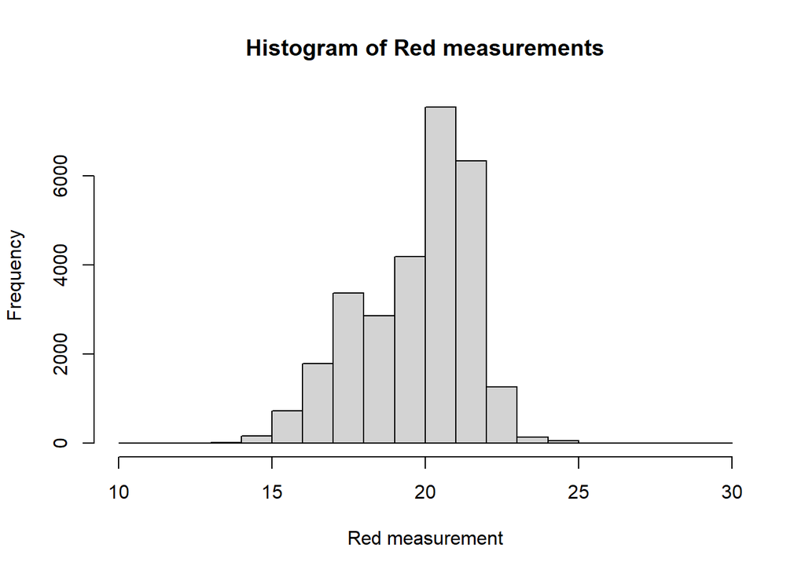

```r
hist(data_train$r, main='Histogram of Red measurements', xlab='Red measurement')
```

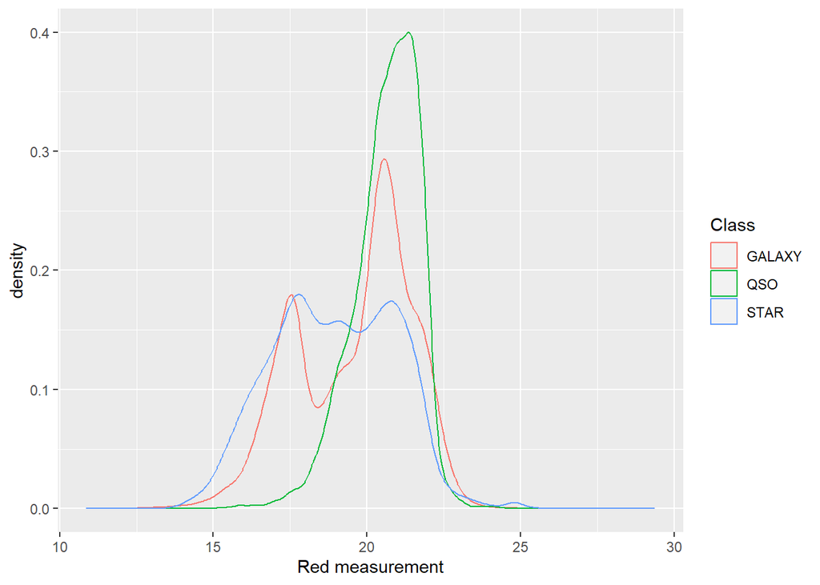

```r
ggplot(data_train, aes(x=r, color=Class)) +
  geom_density() +
  labs(x="Red measurement")
```

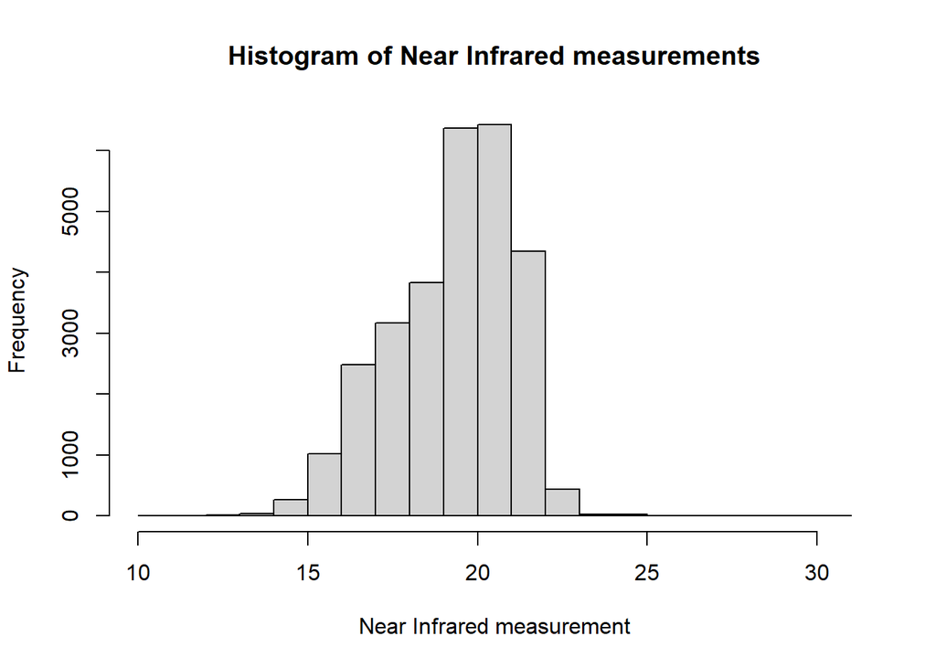

```r
hist(data_train$i, main='Histogram of Near Infrared measurements', xlab='Near Infrared measurement')
```

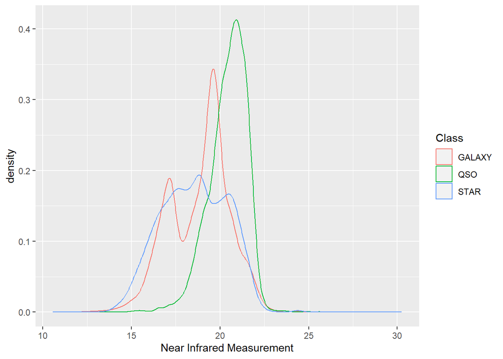

```r
ggplot(data_train, aes(x=i, color=Class)) +
  geom_density() +
  labs(x="Near Infrared Measurement")
```

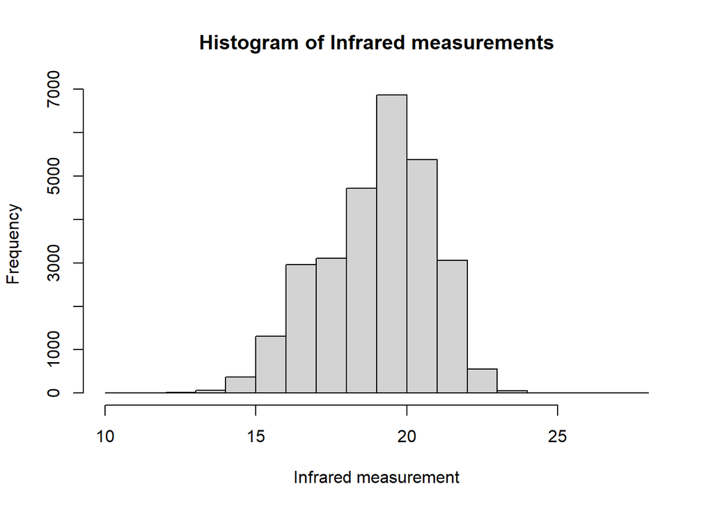

```r
hist(data_train$z, main='Histogram of Infrared measurements', xlab='Infrared measurement')
```

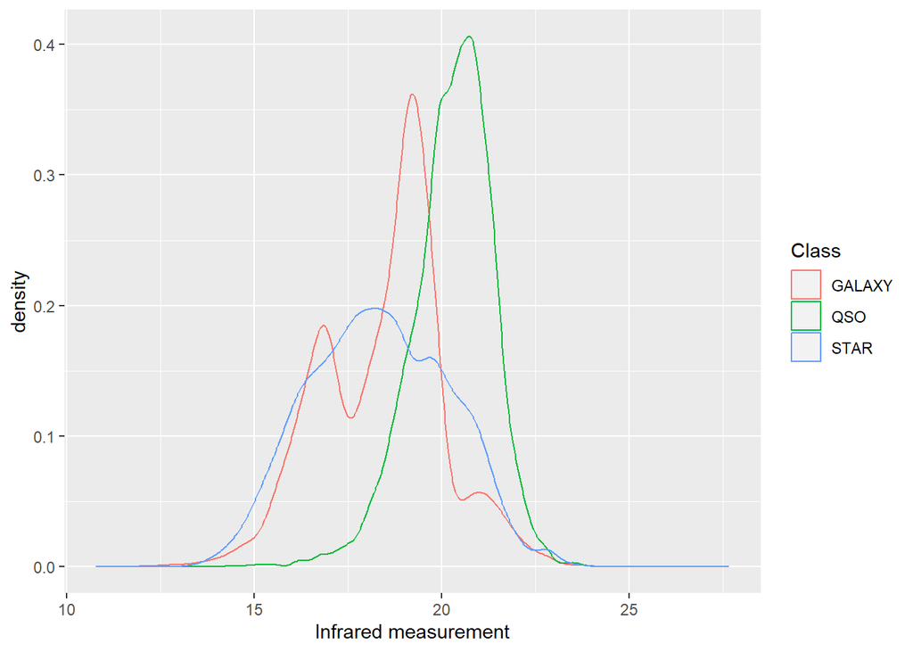

```r
ggplot(data_train, aes(x=z, color=Class)) +
  geom_density() +
  labs(x="Infrared measurement")
```

### run_ID

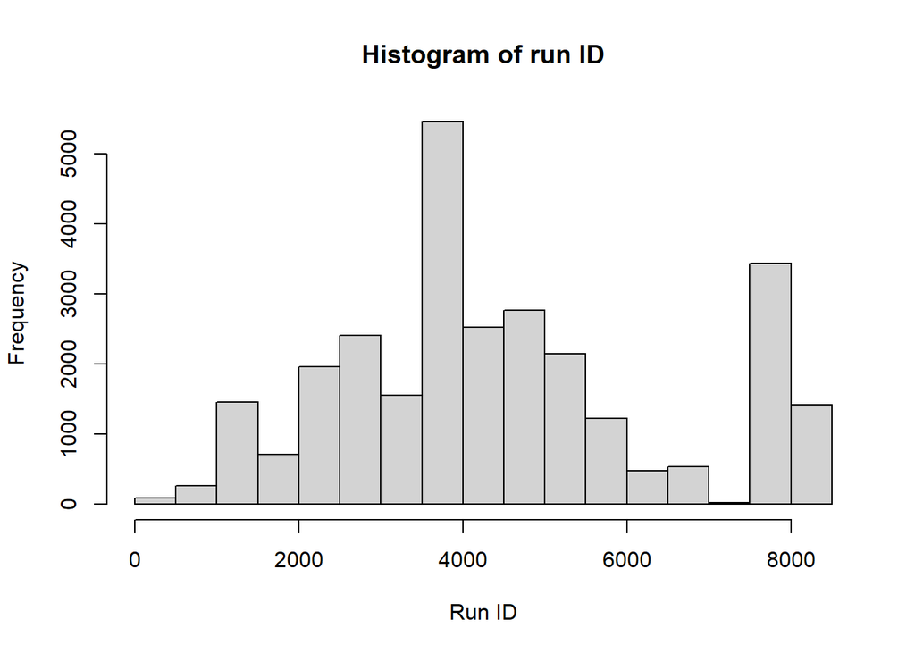

```r
hist(data_train$run_ID, main='Histogram of run ID', xlab='Run ID')
```

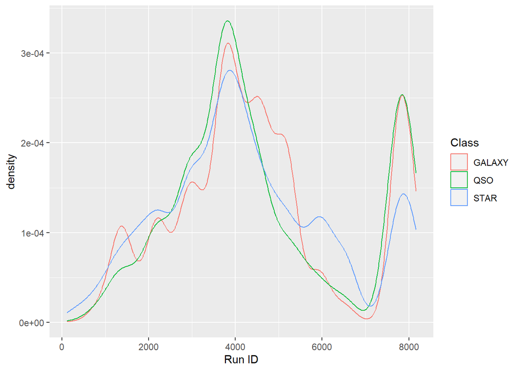

```r
ggplot(data_train, aes(x=run_ID, color=Class)) +
  geom_density() +
  labs(x="Run ID")
```

### rerun_ID

The main thing to notice in the `rerun_ID` variable is that it only takes one unique value for every single observation:

```r
unique(data$rerun_ID) # check all different instances of rerun_ID
```

```
## [1] 301
```

Therefore, this observation can be easily removed without losing any information.

```r
data_train = subset(data_train, select = -rerun_ID)
data_test = subset(data_test, select = -rerun_ID)
```

### cam_col

```r
table(data_train$cam_col)
```

```
##
##    1    2    3    4    5    6
## 3699 4908 5386 5548 5146 3756
```

```r
unique(data_train$cam_col) # show the different values of cam_col
```

```
## [1] 4 5 3 2 6 1
```

When checking the different values of the variable `cam_col`, we notice that it only takes 6 values. Given this, it might me more convenient to turn this variable into a categorical one.

```r
data_train$cam_col = factor(data_train$cam_col)
data_test$cam_col = factor(data_test$cam_col)
```

Now, we can check whether there are any significant differences in terms of this variable between the three groups:

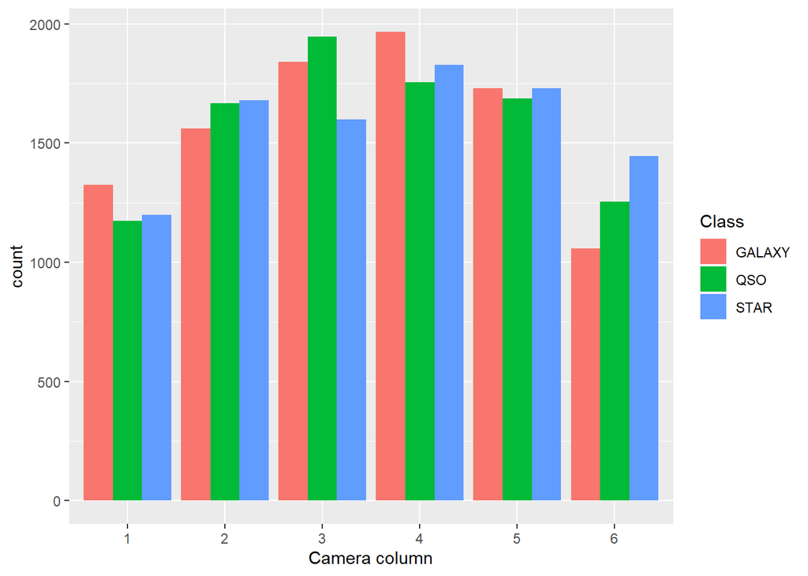

```r
ggplot(data_train, aes(x=cam_col, fill=Class)) +
  geom_bar(position=position_dodge()) +
  xlab("Camera column")
```

There does not seem not be any significant preference of any group for any of the levels of `cam_col`.

### field_ID

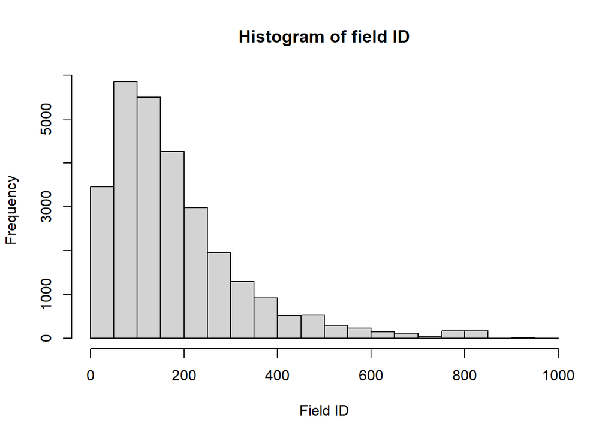

```r
hist(data_train$field_ID, main='Histogram of field ID', xlab='Field ID')
```

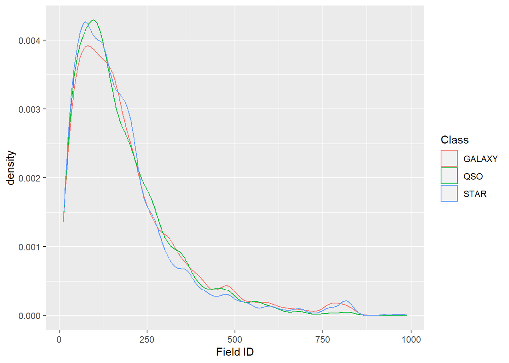

```r
ggplot(data_train, aes(x=field_ID, color=Class)) +
  geom_density() +
  labs(x="Field ID")
```

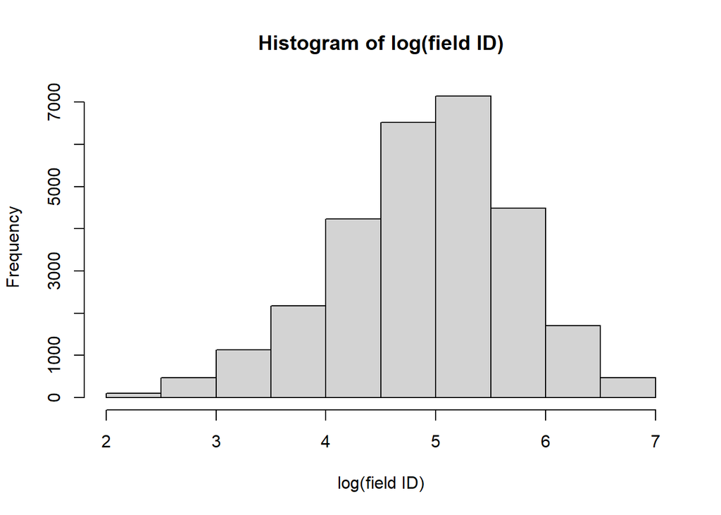

```r
data_train$field_ID = log(data_train$field_ID)
data_test$field_ID = log(data_test$field_ID)

hist(data_train$field_ID, main='Histogram of log(field ID)', xlab='log(field ID)')
```

### spec_obj_ID

The `spec_obj_ID` can be problematic. It is a specific identifier of an object, although a same number could be associated to different values of photometric measurements, depending on the rest of the characteristics of the measurements. As long as this identifier is the same, the classification should obviously be the same.

```r
length(unique(data$spec_obj_ID))
```

```
## [1] 56883
```

However, we can see that in the whole dataset there are as many `spec_obj_ID` as observations, meaning that there are no repeated objects. This allows us to remove this variable without losing information.

```r
data_train = subset(data_train, select = -spec_obj_ID)
data_test = subset(data_test, select = -spec_obj_ID)
```

### redshift

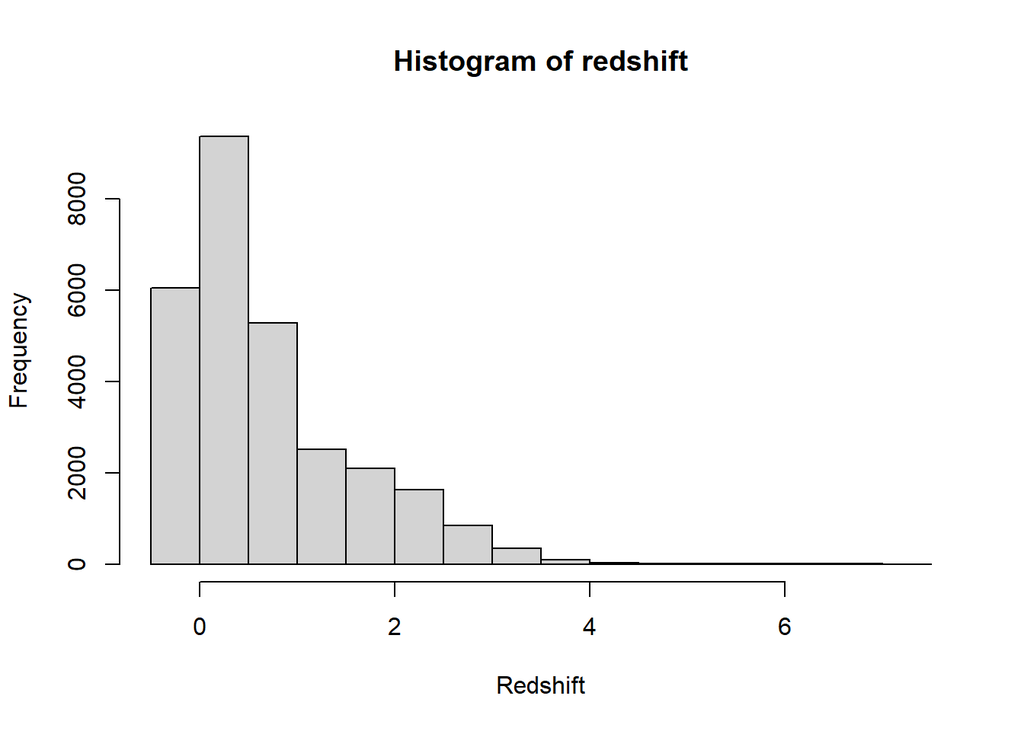

```r
hist(data_train$redshift, main='Histogram of redshift', xlab='Redshift')
```

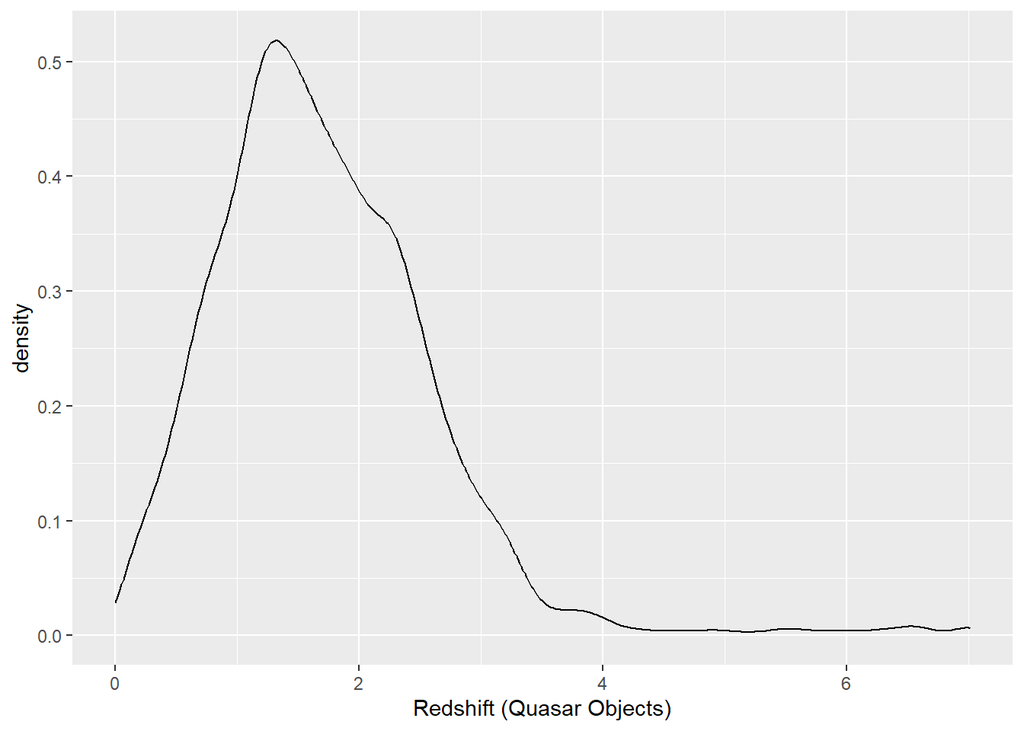

```r
ggplot(data_train[data_train$Class == "QSO",], aes(x=redshift)) +
  geom_density() +
  labs(x="Redshift (Quasar Objects)")
```

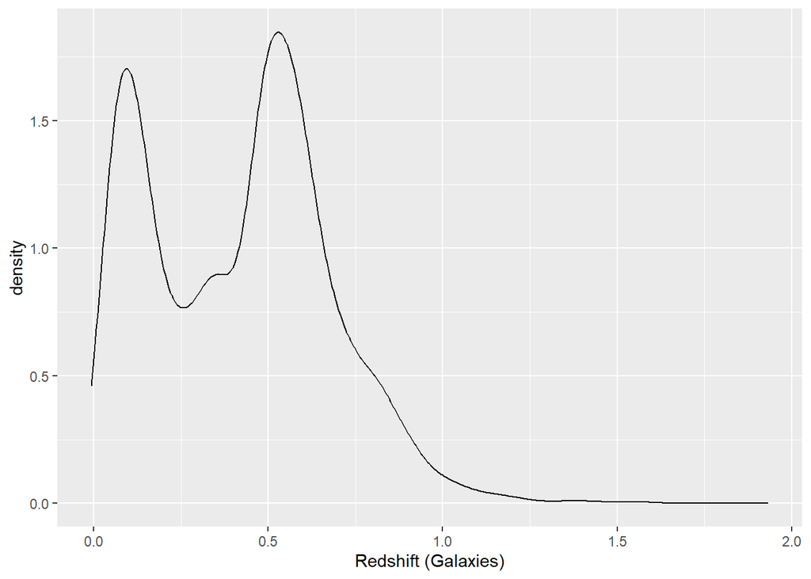

```r
ggplot(data_train[data_train$Class == "GALAXY",], aes(x=redshift)) +
  geom_density() +
  labs(x="Redshift (Galaxies)")
```

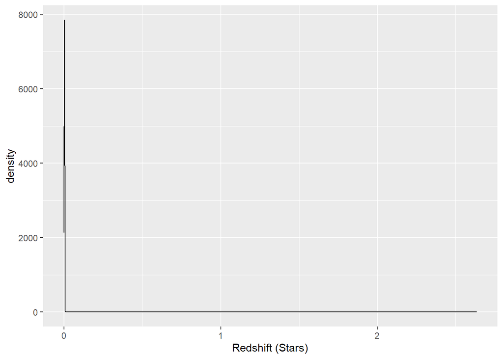

```r
ggplot(data_train[data_train$Class == "STAR",], aes(x=redshift)) +
  geom_density() +
  labs(x="Redshift (Stars)")
```

### plate

The overall distribution of the `plate` variable seems to be either slightly normal-like or slightly uniform, so no transformations will be needed. The interesting aspect of this variable is the fact that the densities for each group differ so greatly. This might hint at its importance when being used to identify the three different groups.

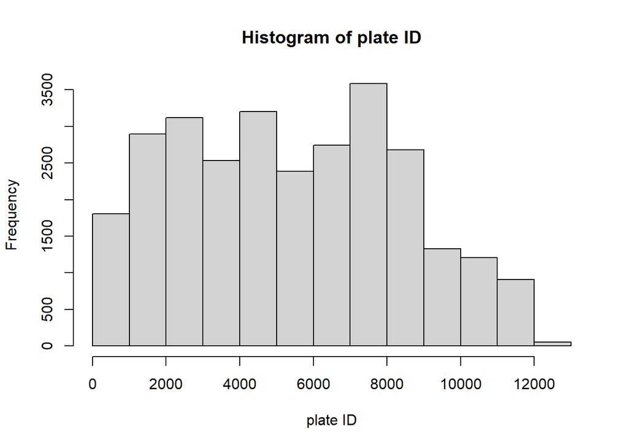

```r
hist(data_train$plate, main='Histogram of plate ID', xlab='plate ID')
```

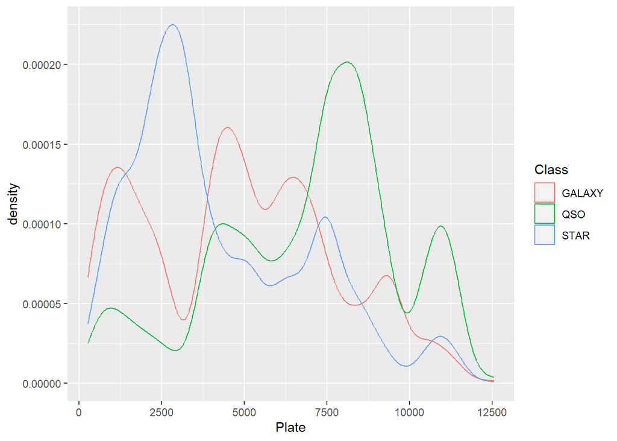

```r
ggplot(data_train, aes(x=plate, color=Class)) +
  geom_density() +
  labs(x="Plate")
```

### MJD

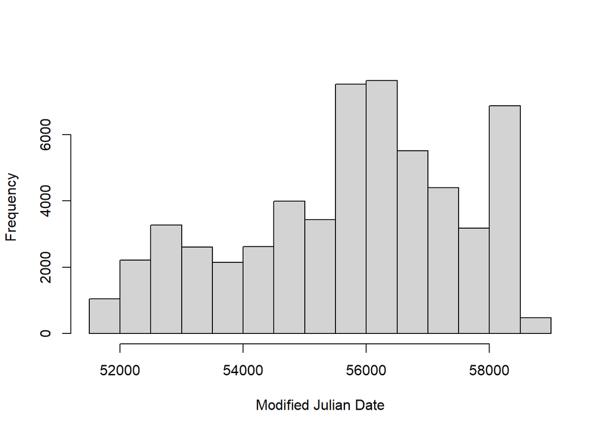

```r
hist(data$MJD, main='', xlab='Modified Julian Date')
```

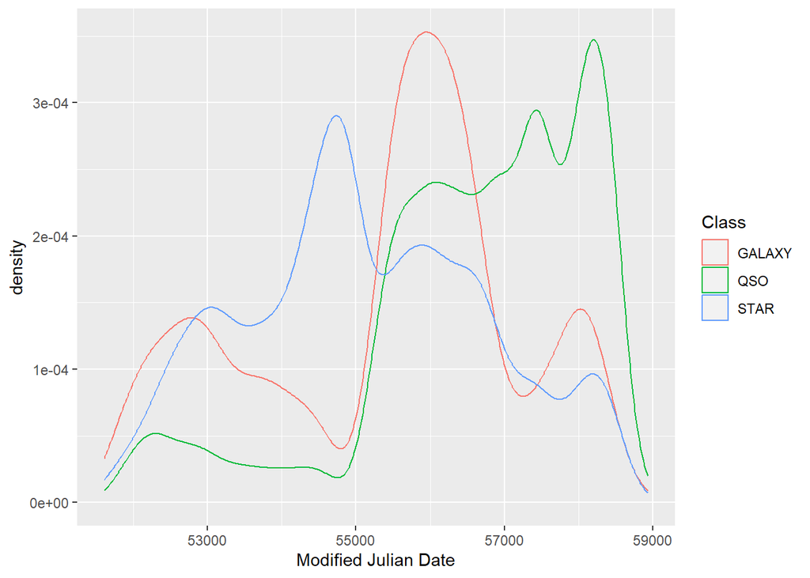

```r
ggplot(data_train, aes(x=MJD, color=Class)) +
  geom_density() +
  labs(x="Modified Julian Date")
```

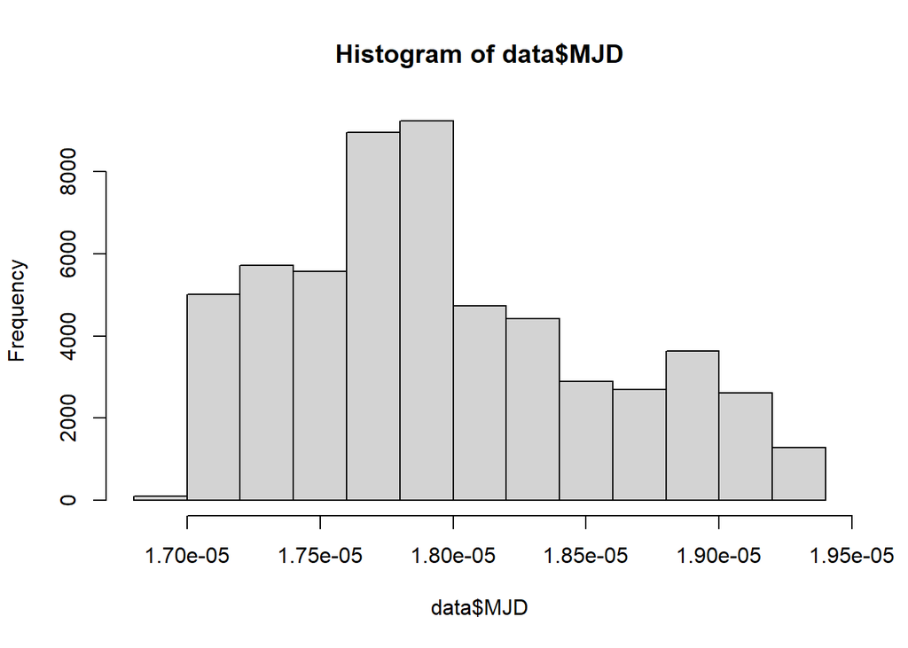

```r
data$MJD = 1/data$MJD

hist(data$MJD)
```

One other feature of this variable that should be mentioned is that, just like in the case of `plate` and `redshift``, the different shapes of the distributions depending on the class might make this an important variables when it comes to differentiating between stellar objects.